## **CPLE6**

Na manhã de sexta-feira, 22 de agosto de 2025, a ação CPLE6 apresentou um desempenho notável, com o fechamento diário alcançando R$ 12,12. Isso representa uma variação positiva de 2,19% em relação ao dia anterior, quando encerrou em R$ 11,86.A abertura do dia também foi animadora, com o preço abrindo em R$ 11,89. No entanto, o que chamou a atenção foi um ponto de negociação anômalo às 13:03:00s, quando uma quantidade significativa de negócios foi realizada, correspondendo a 10,94% do volume total negociado no dia para o ativo CPLE6. Essa situação contribuiu para uma variação de 1,315% na cotação do ativo logo após esse ponto.Além disso, é importante notar que a ação CPLE6 apresentou uma variação mensal de 2,11%, trimestral de -2,73% e anual de 33,8%. Essa evolução em longo prazo também pode ter influenciado o desempenho da ação no dia. Veja a seguir o gráfico do intraday com o destaque do outlier: as setas amarelas destacam o momento e o volume negociado no ponto de outlier. A linha violeta demonstra a tendência do preço antes e depois do destaque.

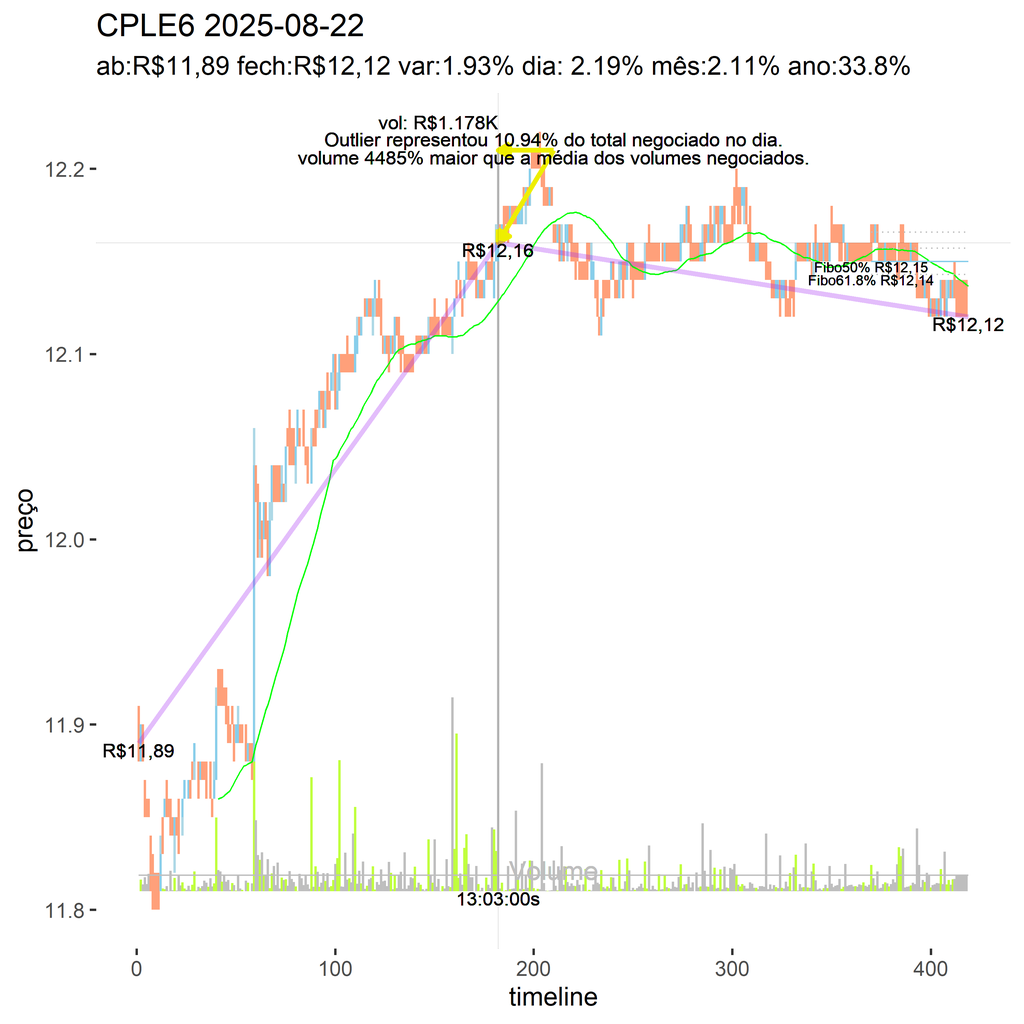

A seguir, desempenho do ativo ao longo do tempo:

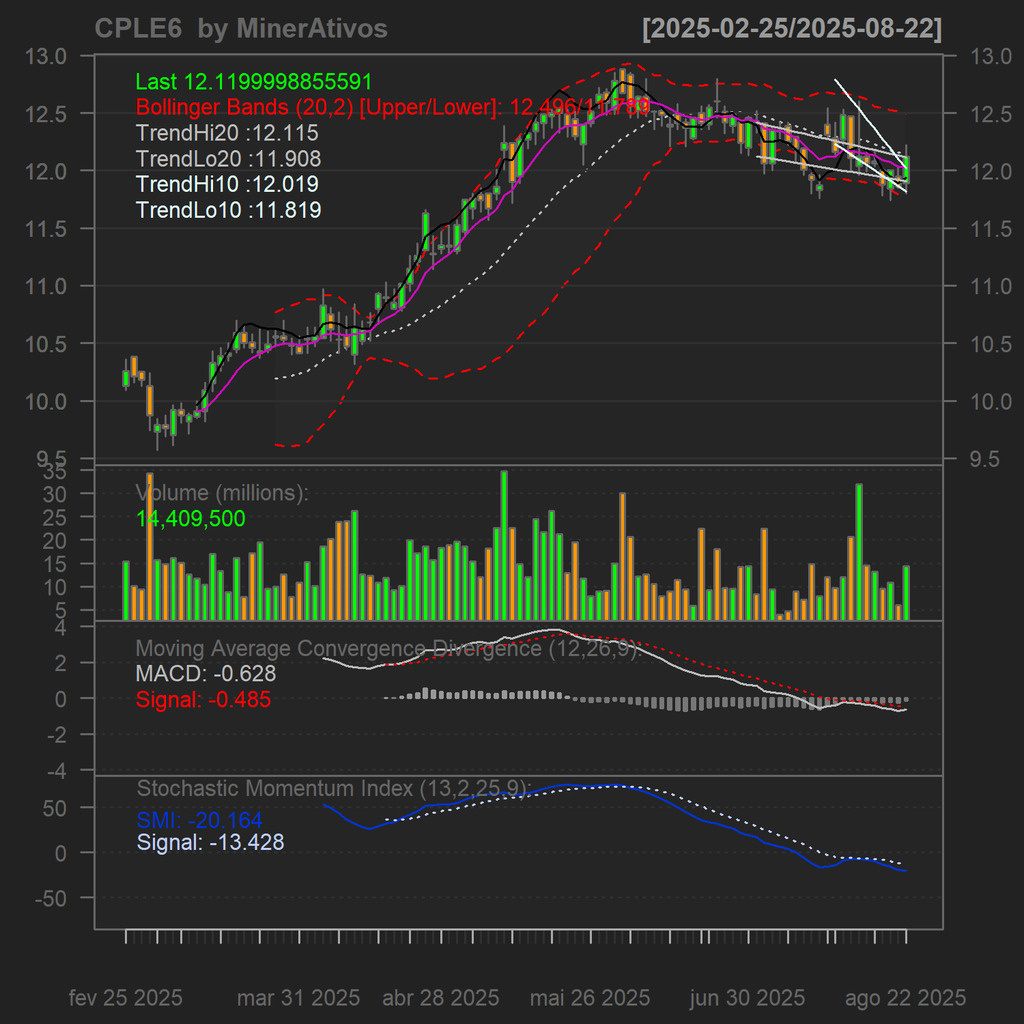

[figure not shown]